# Introduction to Visualization in R

Ayush Pandey

**ASCE T&DI Workshop**

# **Dataset A**

## Setting Up the Workspace

### Libraries & Packages

```r
library(tidyverse)
```

### Load Data

Load all the files and merge them into a single dataframe.

```r
df1 <- read.csv("C:/Users/johan/Box/05 Repositories/RLab/ASCE T&DI_Visualization in R/R-wrkshop_1.csv")
df2 <- read.csv("C:/Users/johan/Box/05 Repositories/RLab/ASCE T&DI_Visualization in R/R-wrkshop_2.csv")
df3 <- read.csv("C:/Users/johan/Box/05 Repositories/RLab/ASCE T&DI_Visualization in R/R-wrkshop_3.csv")
df4 <- read.csv("C:/Users/johan/Box/05 Repositories/RLab/ASCE T&DI_Visualization in R/R-wrkshop_4.csv")

df <- bind_rows(df1, df2, df3, df4)
```

## Exploratory Data Analysis

### General Inspection

```r
names(df)
```

```
##  [1] "Unnamed..0"          "request_datetime"    "on_scene_datetime"
##  [4] "pickup_datetime"     "dropoff_datetime"    "PULocationID"
##  [7] "DOLocationID"        "trip_miles"          "trip_time"
## [10] "base_passenger_fare" "tips"                "driver_pay"
## [13] "TNC"                 "shared_requested"    "shared_matched"
## [16] "Borough"             "Zone"                "Borough_d"
## [19] "Zone_d"              "wait_time"
```

```r
View(df)

df <- df %>% select(pickup_datetime, TNC, trip_miles, trip_time, base_passenger_fare, Zone_d, Borough)

df %>% summary()
```

```
##  pickup_datetime        TNC              trip_miles        trip_time
##  Length:421544      Length:421544      Min.   :  0.100   Min.   :  120
##  Class :character   Class :character   1st Qu.:  1.779   1st Qu.:  697
##  Mode  :character   Mode  :character   Median :  3.220   Median : 1088
##                                        Mean   :  4.552   Mean   : 1275
##                                        3rd Qu.:  5.546   3rd Qu.: 1641
##                                        Max.   :141.760   Max.   :27119
##  base_passenger_fare    Zone_d            Borough
##  Min.   :-26.57      Length:421544      Length:421544
##  1st Qu.: 13.04      Class :character   Class :character
##  Median : 19.66      Mode  :character   Mode  :character
##  Mean   : 24.01
##  3rd Qu.: 30.31
##  Max.   :678.80
```

```r
df %>% filter(base_passenger_fare > 0) %>% summary()
```

```
##  pickup_datetime        TNC              trip_miles        trip_time
##  Length:421099      Length:421099      Min.   :  0.100   Min.   :  120
##  Class :character   Class :character   1st Qu.:  1.780   1st Qu.:  697
##  Mode  :character   Mode  :character   Median :  3.220   Median : 1088
##                                        Mean   :  4.552   Mean   : 1275
##                                        3rd Qu.:  5.545   3rd Qu.: 1641
##                                        Max.   :141.760   Max.   :27119
##  base_passenger_fare    Zone_d            Borough
##  Min.   :  0.05      Length:421099      Length:421099
##  1st Qu.: 13.10      Class :character   Class :character
##  Median : 19.66      Mode  :character   Mode  :character
##  Mean   : 24.04
##  3rd Qu.: 30.32
##  Max.   :678.80
```

```r
df %>% filter(base_passenger_fare > 0, trip_miles < 15) %>% summary()
```

```
##  pickup_datetime        TNC              trip_miles       trip_time
##  Length:407439      Length:407439      Min.   : 0.100   Min.   :  120
##  Class :character   Class :character   1st Qu.: 1.740   1st Qu.:  686
##  Mode  :character   Mode  :character   Median : 3.110   Median : 1060
##                                        Mean   : 4.063   Mean   : 1226
##                                        3rd Qu.: 5.197   3rd Qu.: 1571
##                                        Max.   :14.999   Max.   :27119
##  base_passenger_fare    Zone_d            Borough
##  Min.   :  0.05      Length:407439      Length:407439
##  1st Qu.: 12.51      Class :character   Class :character
##  Median : 19.49      Mode  :character   Mode  :character
##  Mean   : 22.74
##  3rd Qu.: 28.77
##  Max.   :678.80
```

```r
df <- df %>%
  filter(base_passenger_fare > 0, trip_miles < 15) %>%
  rename(fare = base_passenger_fare) %>%
  mutate(fare_per_mile = fare/trip_miles)
```

## Visualizing Data

### Scattered Plot

Let’s start from scratch.

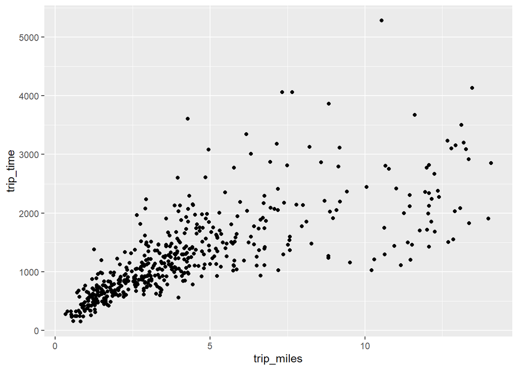

```r
df %>%
  # randomly pick 500 data points
  sample_n(500) %>%
  # send this filtered data to ggplot
  ggplot() +
  # add a layer of scatter plot
  geom_point(aes(x = trip_miles, y = trip_time))
```

We can now add some colors, and a colormap.

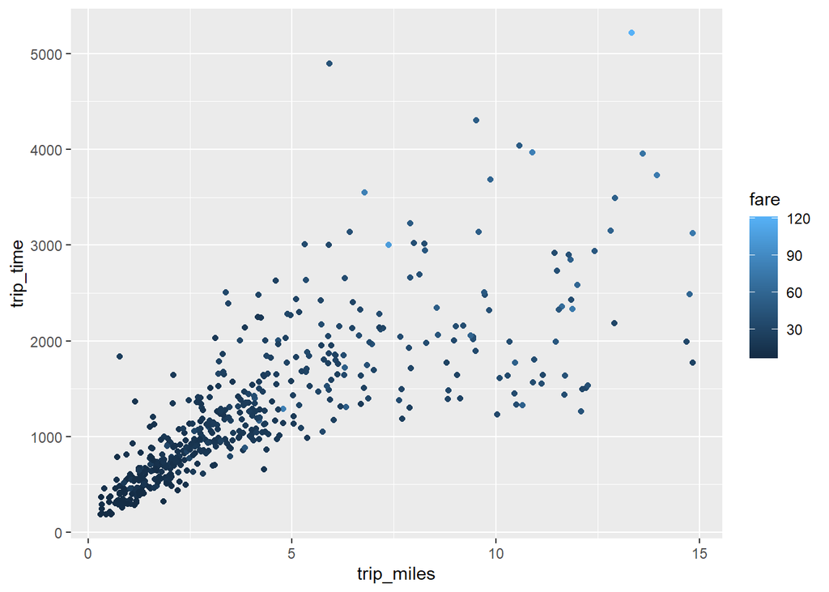

```r
df %>%
  sample_n(500) %>%
  ggplot() +
  geom_point(aes(x = trip_miles, y = trip_time, color = fare))
```

### Regression Line Now let’s add a regression line.

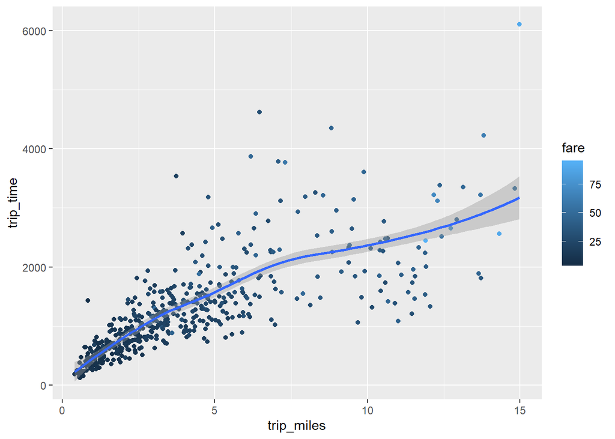

```r
df %>%
  sample_n(500) %>%
  ggplot() +
  geom_point(aes(x = trip_miles, y = trip_time, color = fare)) +
  geom_smooth(aes(x = trip_miles, y = trip_time))
```

We could use another categorization for formatting the scatter plot, and build the regression lines accordingly.

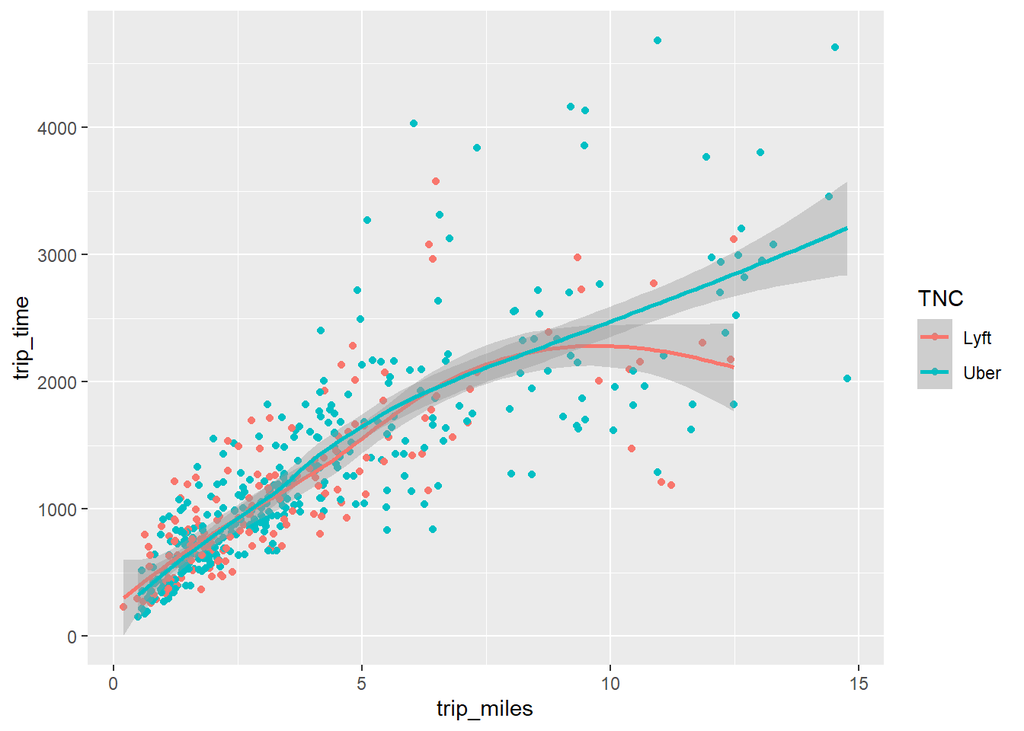

```r
df %>%
  sample_n(500) %>%
  ggplot() +
  geom_point(aes(x = trip_miles, y = trip_time, color = TNC)) +
  geom_smooth(aes(x = trip_miles, y = trip_time, color = TNC))
```

### Line Plot Let’s try a line plot instead.

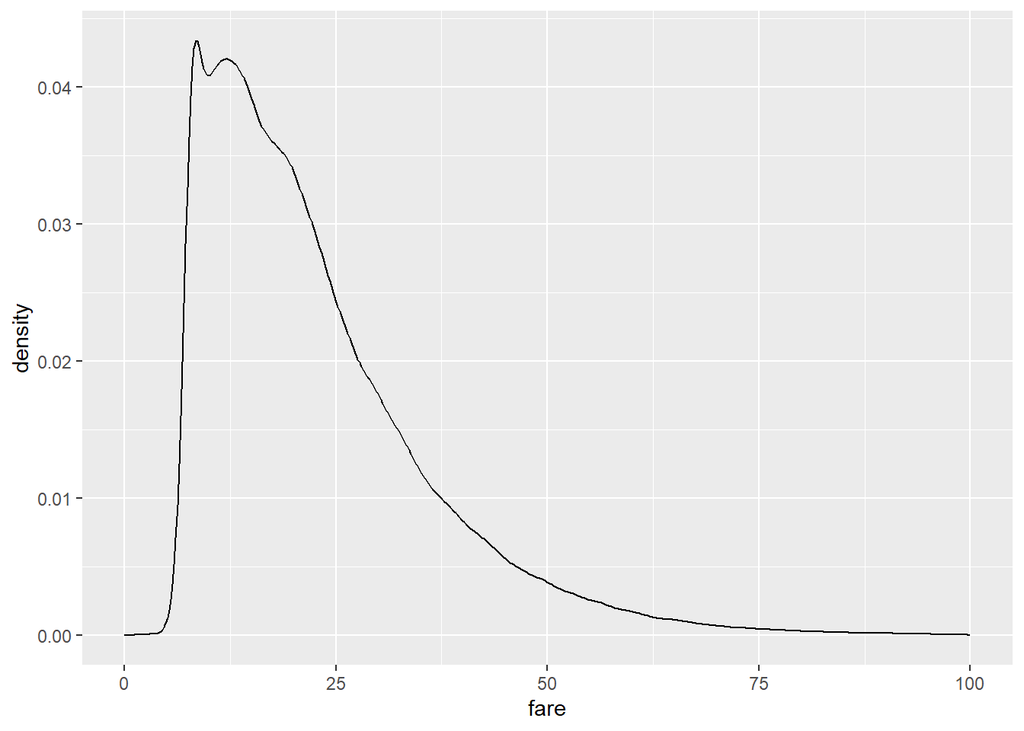

```r
df %>%
  ggplot() +
  geom_density(aes(x = fare)) +
  xlim(0, 100)
```

We could fill the regions covered by the curve and set a transparency factor.

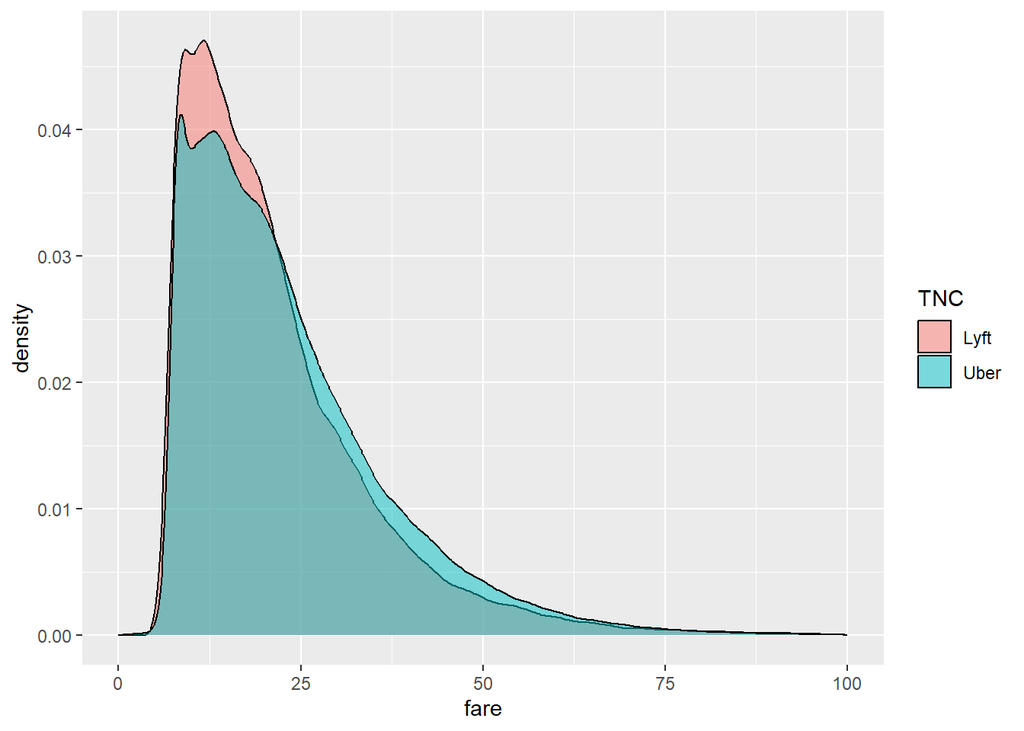

```r
df %>%
  ggplot() +
  geom_density(aes(x = fare, fill = TNC), alpha = 0.5) +
  xlim(0, 100)
```

### Violin Plot

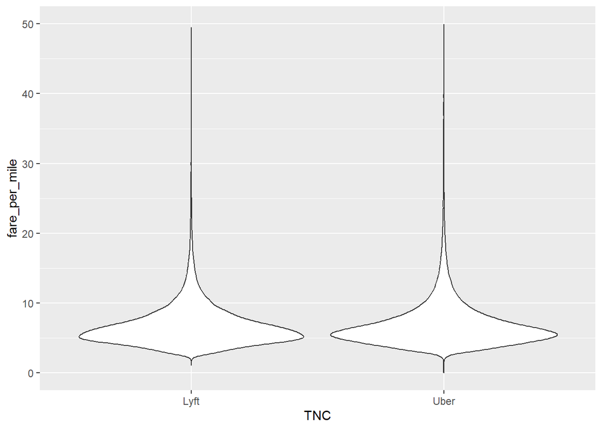

```r
df %>%
  ggplot() +
  geom_violin(aes(x = TNC, y = fare_per_mile)) +
  ylim(0, 50)
```

### Scattered Plot: A Different View

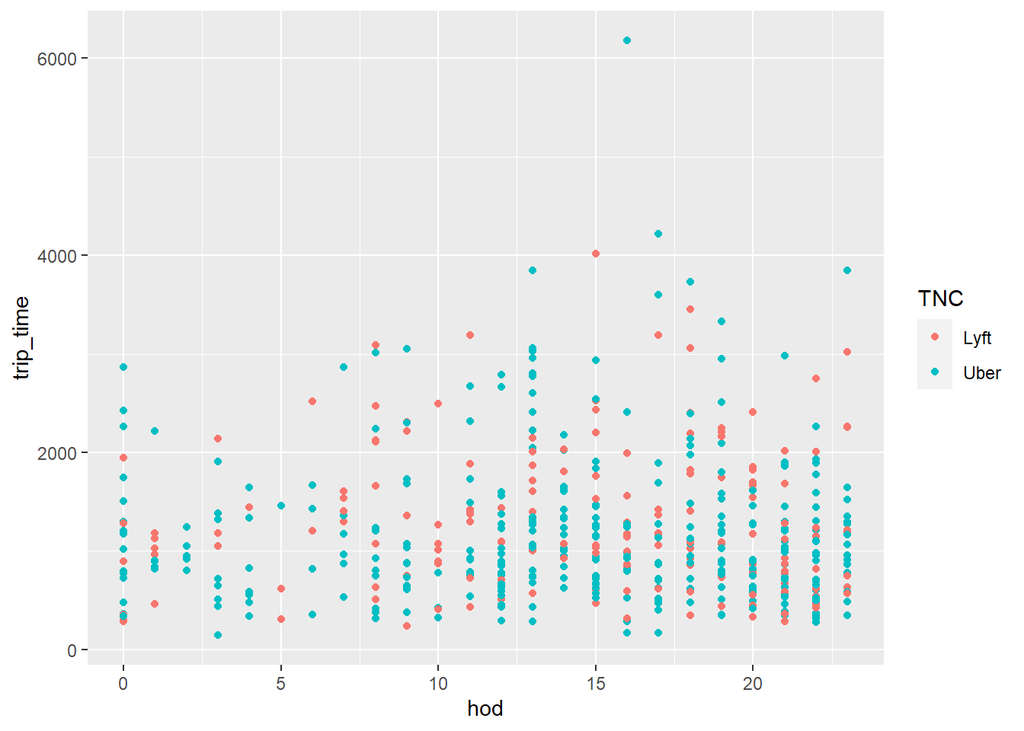

```r
df %>%
  sample_n(500) %>%
  mutate(hod = hour(pickup_datetime)) %>%
  ggplot() +
  geom_point(aes(x= hod, y = trip_time, color = TNC))
```

Let’s group the data before generating other visualizations:

```r
df %>%
  mutate(hod = hour(pickup_datetime)) %>%
  group_by(hod) %>%
  summarize(mean_trip_time = mean(trip_time),
            mean_trip_miles = mean(trip_miles),
            sd_trip_time = sd(trip_time),
            sd_trip_miles = sd(trip_miles)) %>%
  summary()
```

```
##       hod        mean_trip_time   mean_trip_miles  sd_trip_time
##  Min.   : 0.00   Min.   : 931.5   Min.   :3.577   Min.   :437.4
##  1st Qu.: 5.75   1st Qu.:1044.7   1st Qu.:3.889   1st Qu.:530.5
##  Median :11.50   Median :1268.2   Median :4.050   Median :705.1
##  Mean   :11.50   Mean   :1207.7   Mean   :4.346   Mean   :677.4
##  3rd Qu.:17.25   3rd Qu.:1334.1   3rd Qu.:4.294   3rd Qu.:781.2
##  Max.   :23.00   Max.   :1482.7   Max.   :6.596   Max.   :981.0
##  sd_trip_miles
##  Min.   :2.652
##  1st Qu.:2.819
##  Median :3.257
##  Mean   :3.218
##  3rd Qu.:3.414
##  Max.   :4.071
```

### Plotting Trends

[output not shown]

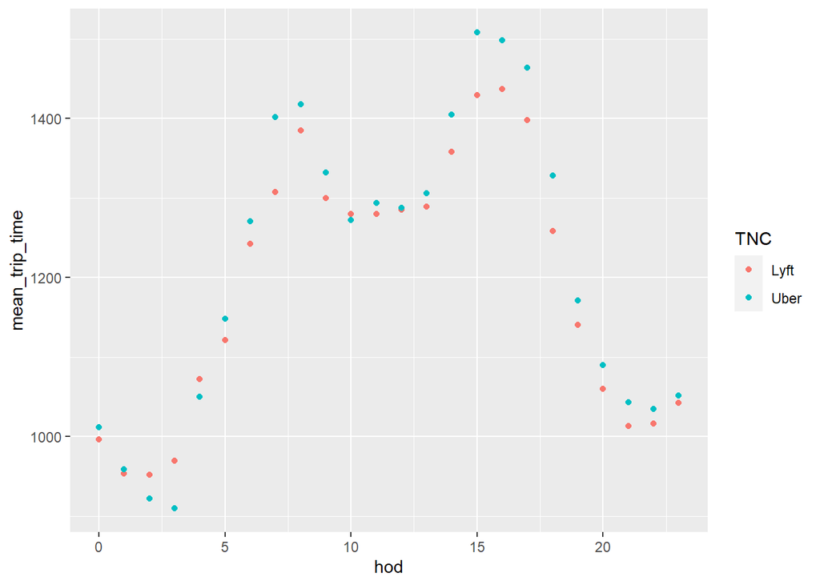

```r
df %>%
  mutate(hod = hour(pickup_datetime)) %>%
  group_by(hod, TNC) %>%
  summarize(mean_trip_time = mean(trip_time),
            mean_trip_miles = mean(trip_miles),
            sd_trip_time = sd(trip_time),
            sd_trip_miles = sd(trip_miles)) %>%
  ggplot() +
  geom_point(aes(x = hod, y = mean_trip_time, color = TNC))
```

### Line Plot (With Markers)

[output not shown]

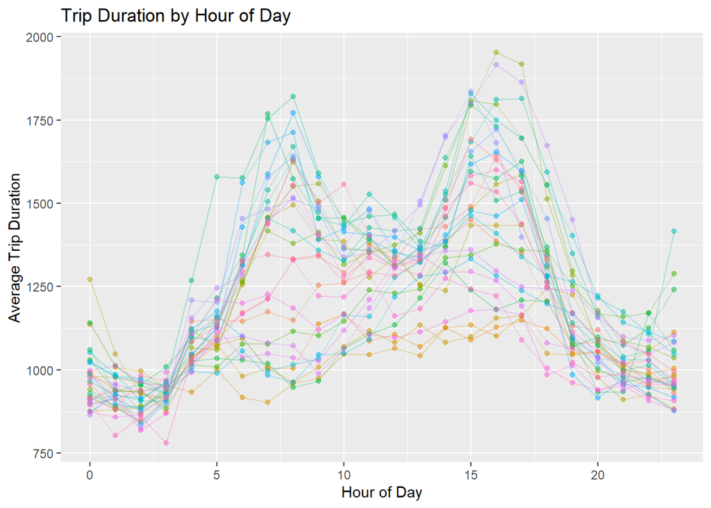

```r
df %>%
  mutate(hod = hour(pickup_datetime),
         date = day(pickup_datetime)) %>%
  group_by(hod, date) %>%
  summarise(mean_trip_time = mean(trip_time)) %>%
  ggplot() +
  geom_point(aes(x = hod, y = mean_trip_time, color = factor(date)), alpha = 0.5) +
  geom_line(aes(x = hod, y = mean_trip_time, color = factor(date)), alpha = 0.3) +
  theme(legend.position = "none") +
  xlab("Hour of Day") +
  ylab("Average Trip Duration") +
  ggtitle("Trip Duration by Hour of Day")
```

# **Dataset B**

## Setting Up the Workspace

### Libraries & Packages

```r
library(sf)
```

### Load Data

```r
shpf <- read_sf("C:/Users/johan/Box/05 Repositories/RLab/ASCE T&DI_Visualization in R/taxi_zones/taxi_zones.shp")
```

## Exploratory Data Analysis

### General Inspection

```r
names(shpf)
```

```
## [1] "OBJECTID"   "Shape_Leng" "Shape_Area" "zone"       "LocationID"
## [6] "borough"    "geometry"
```

```r
View(shpf)
```

## Visualizing Data

### Map Plot

The range of colors can be manually set from a low to high end.

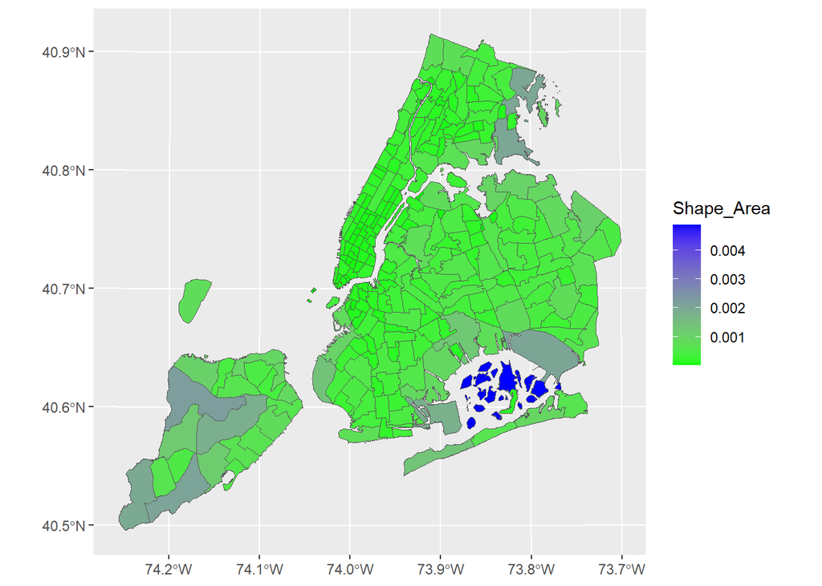

```r
# Map plotted
shpf %>%
  ggplot() +
  geom_sf(aes(fill = Shape_Area)) +
  scale_fill_continuous(low = 'green', high = 'blue')
```

We can group the data by zones to visualize the data in a different way.

```r
ndf <- df %>%
  group_by(Zone_d) %>%
  summarize(trips = n())
```

Let’s specify the number of zones as criteria for coloring the map. The color range will be based on the number of trips.

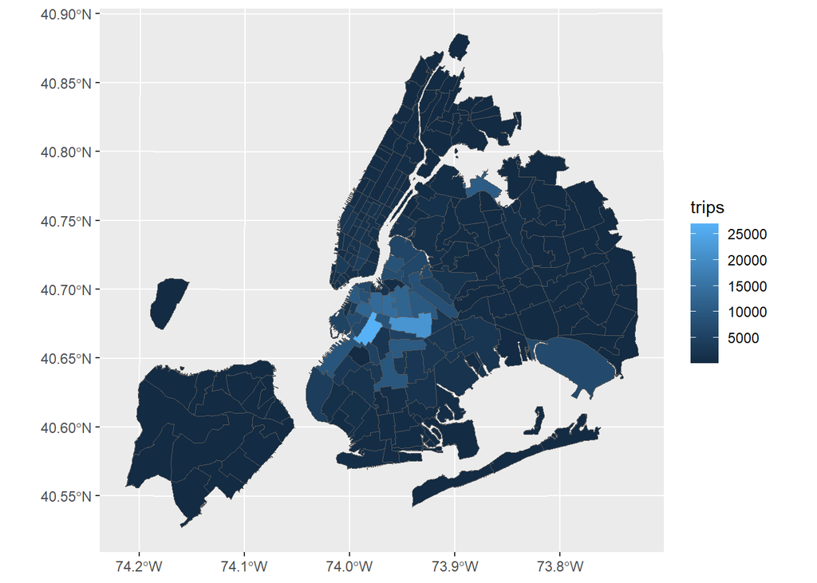

```r
merge(shpf, ndf, by.x = "zone", by.y = "Zone_d") %>%
  ggplot() +
  geom_sf(aes(fill = trips))
```

For clarity we could manually specify which colors should be used.

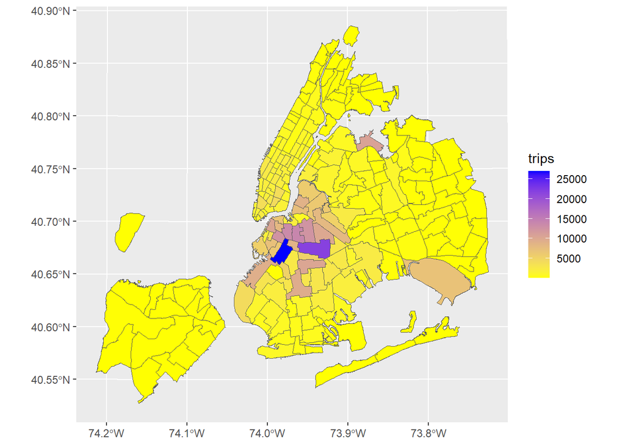

```r
merge(shpf, ndf, by.x = "zone", by.y = "Zone_d") %>%
  ggplot() +
  geom_sf(aes(fill = trips)) +
  scale_fill_gradient2(low = 'red', mid = 'yellow', high = 'blue')
```

There are also predefined colormaps that could enhance our visualizations.

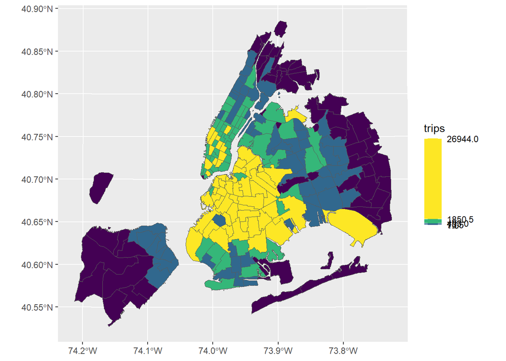

```r
# Final plot with color categories
merge(shpf, ndf, by.x = "zone", by.y = "Zone_d") %>%
  ggplot() +
  geom_sf(aes(fill = trips)) +
  scale_fill_binned(guide = 'colorbar',
                    breaks = as.numeric(quantile(ndf$trips)),
                    type = 'viridis')
```